# Hipotezių testas

Asta Kvedaraitė & Marius Survila

5/18/2020

# Lyginamos grupės: sveiki/sergantys ir jų amžius.

Hipotezė : asmens susirgimas alzheimeriu priklauso nuo amžiaus. H1 : asmuo, suserga alzheimeriu be amžiaus įtakos.

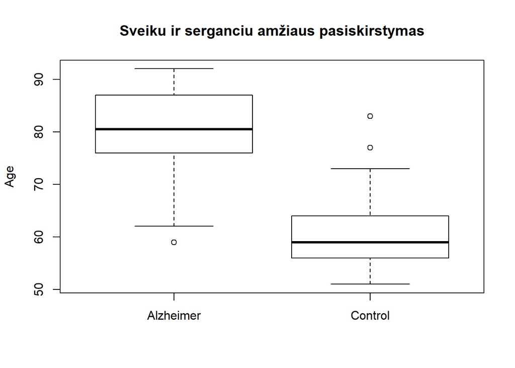

Žemiau, grafike pavaizduotos 5 metilintos eilutės, turinčios didžiausius skirtumus, kurie buvo gauti naudojant T test kiekvienai eilutei. Mūsų reikšmės - mažiausia(0.5562711) ir didžiausia(0.9841318) parodo, jog grafike esančios reikšmės yra teisingai nurodytame rėžyje.

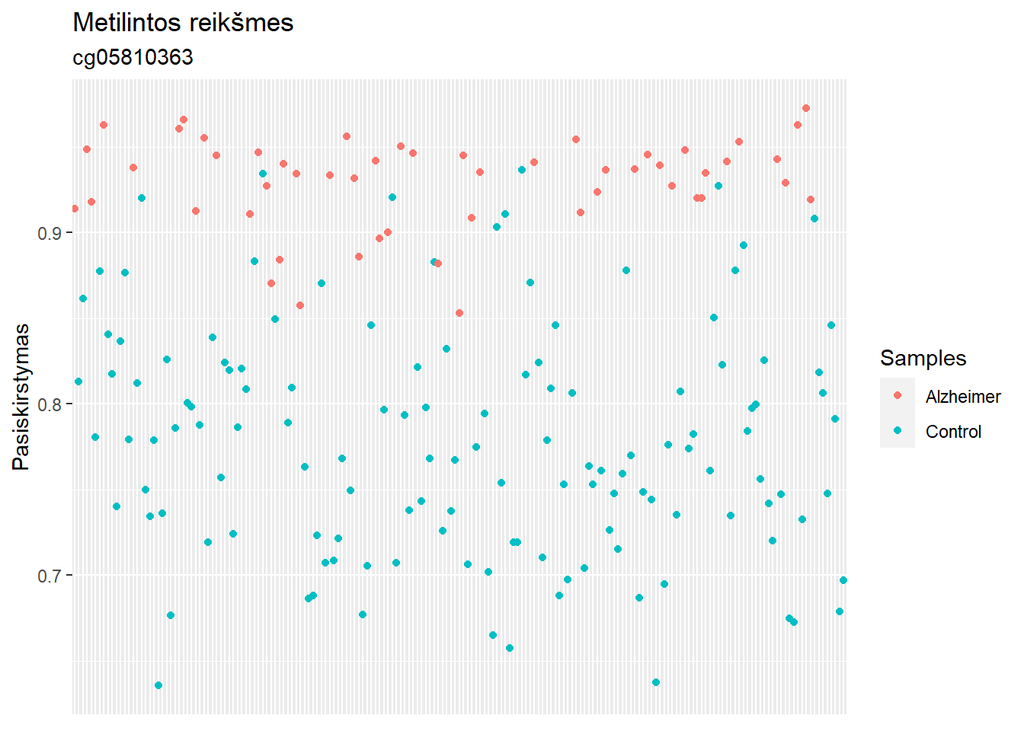

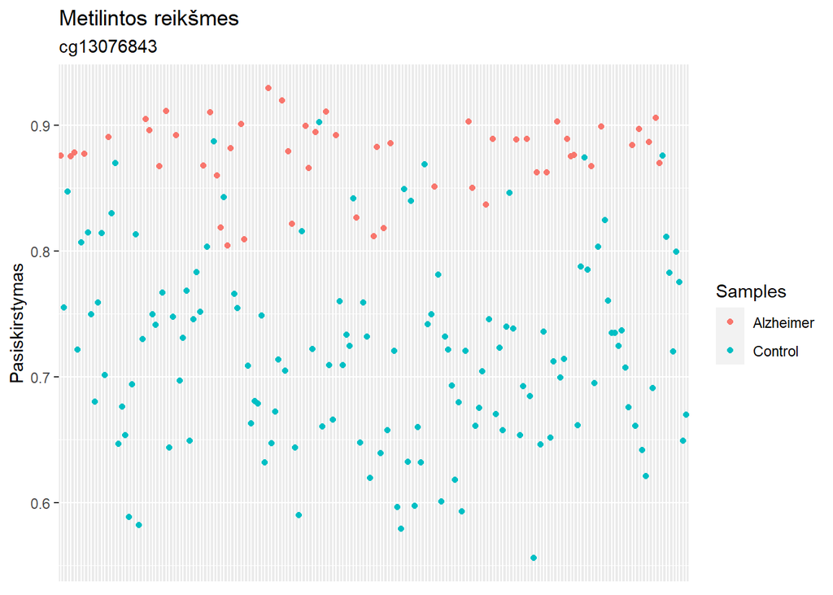

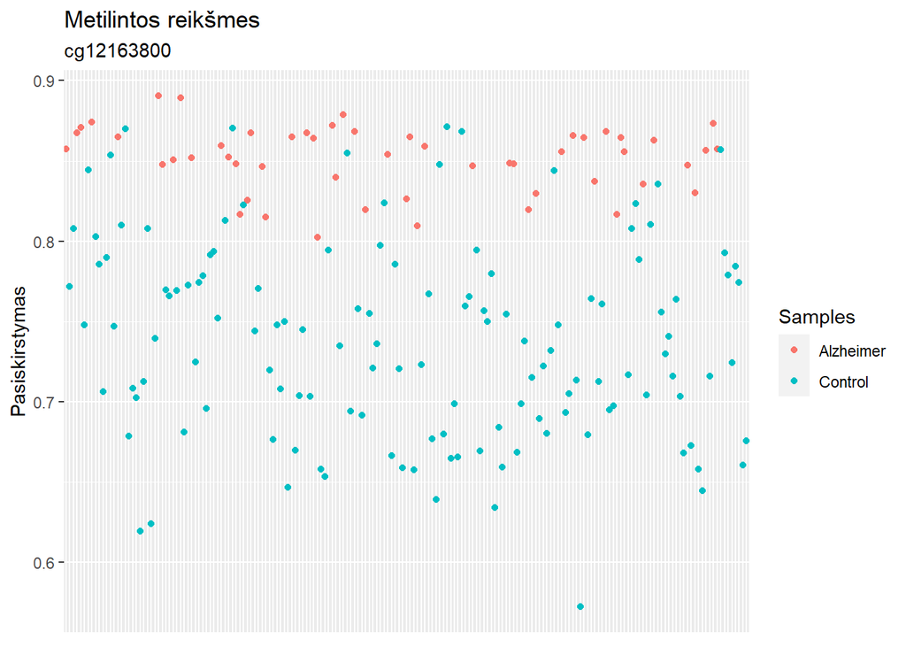

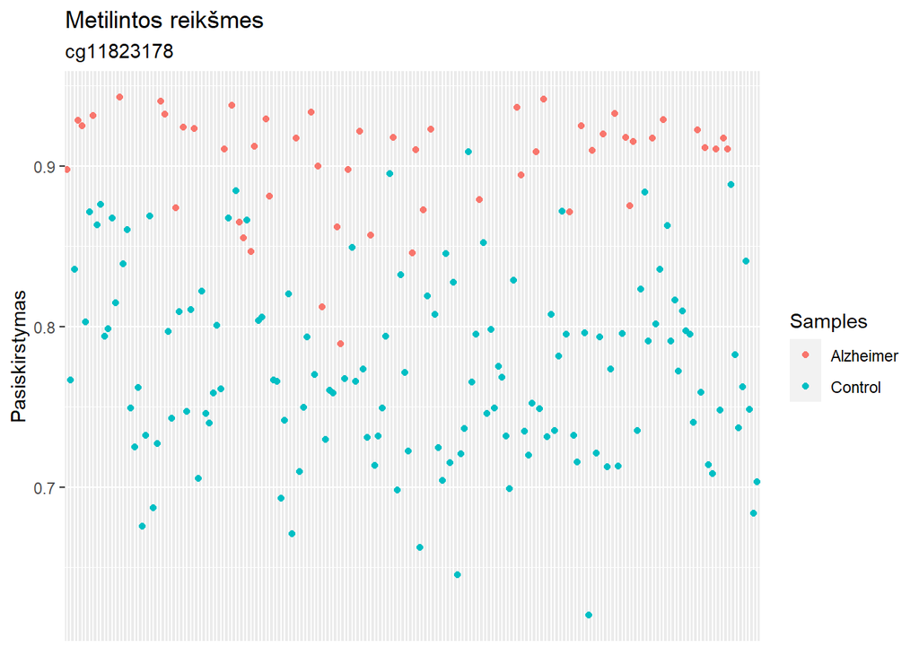

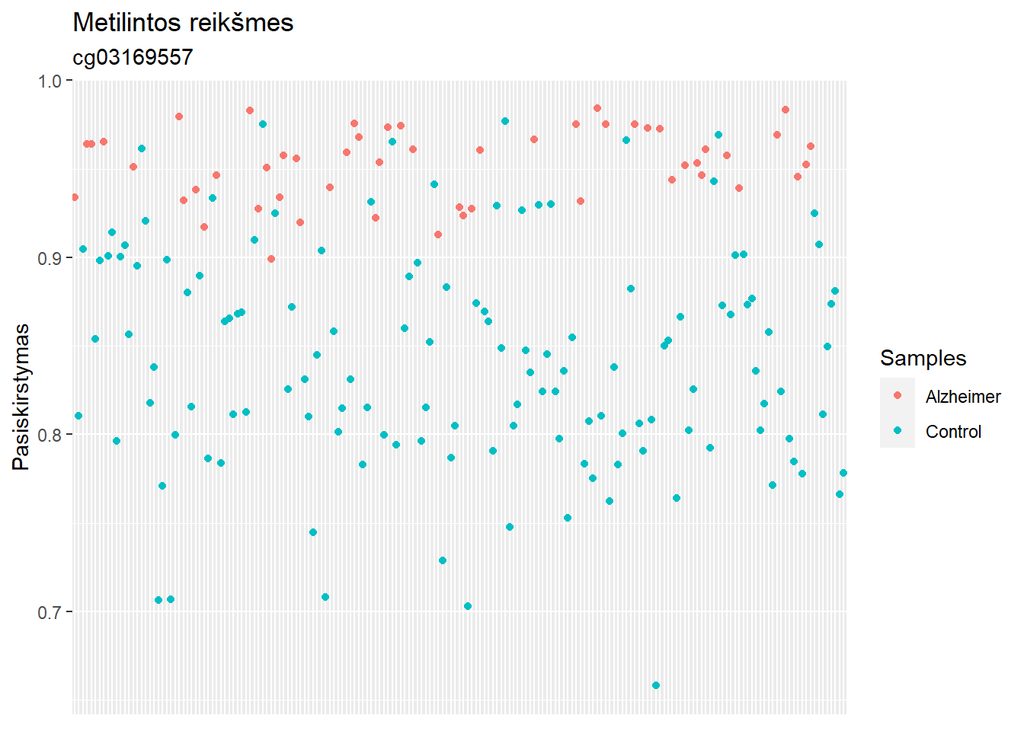

| alfa | Eilutes |
| --- | --- |
| 0.1 | 134972 |
| 0.05 | 98121 |
| 0.01 | 50879 |
| fdr | 36196 |
| bonferroni | 2636 |

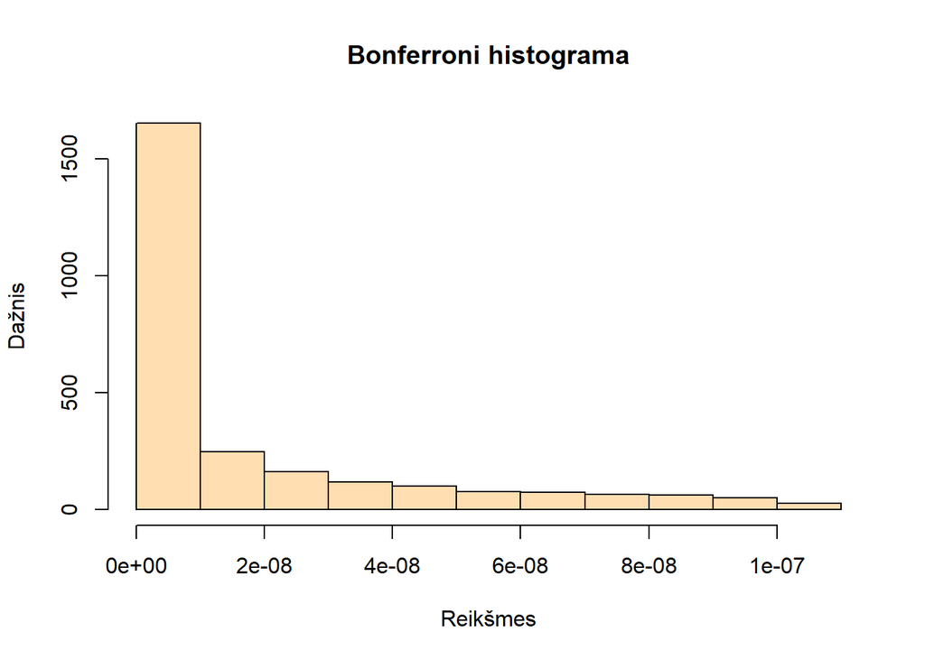

Žemiau pavaizduotas grafikas rodo, kad mažėjant $\alpha$, mažėja reikšmių kiekis (p-reikšmės), kurios yra patikimos. Tačiau po p reikšmių sulyginimo FDR ir Bonferroni metodais, dar labiau sumažėja patikimų p-reikšmių kiekis.

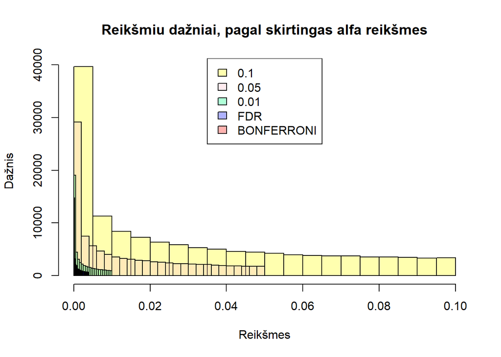

Volcano plot(grafikas) naudojamas daugiausia statistikoje, norint nurodyti p-reikšmes ir atstumą nuo grafo ašies(0). Jis padeda vizualiai identifikuoti genus, kurie turi didesnius atstumus nei kiti. Bioinformatikoje reikšmės pavaizduotos nuo ašies į dešinę pusę yra genai, skatinantys procesus ar kitus atsakus. O į kairę - genai, kurie slopina procesus ar jo atsakus. O į viršų yra bilogiškai reikšmingi genai.

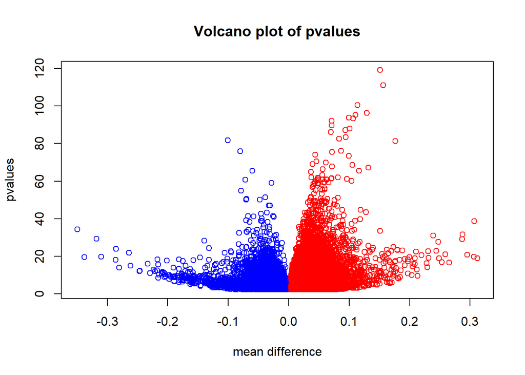

Manhattan plot- yra grafikas, kuris parodo duomenis, kurie labiau išsiskiria iš kitų, p-reikšmėmis. Mažiausios p-reikšmės tampa didžiausiomis pritaikant -log10.

[output not shown]

Tiesinė regresija naudojant amžių ir būseną : serga ar neserga.

Pasirinkta 11 chromosoma, viso turi 28041 eilučių, iš kurių atrinktos patikimos p-value reikšmės.

```
##         alfa Eilutes
## 1        0.1    5224
## 2       0.05    2493
## 3       0.01     735
## 4        fdr    1725
## 5 bonferroni     251
```

Visos reikšmės panašios, pagal atitinkamą $\alpha$ slenkstį.

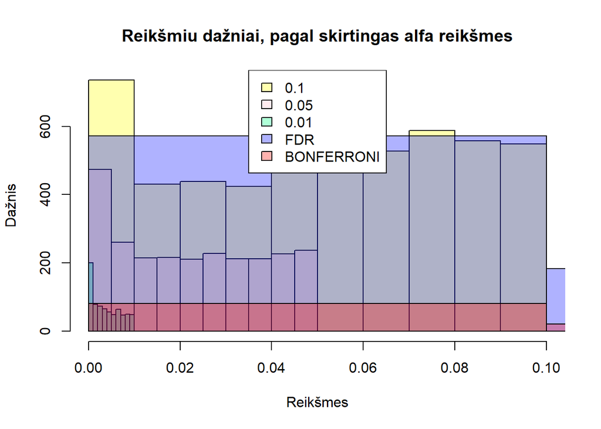

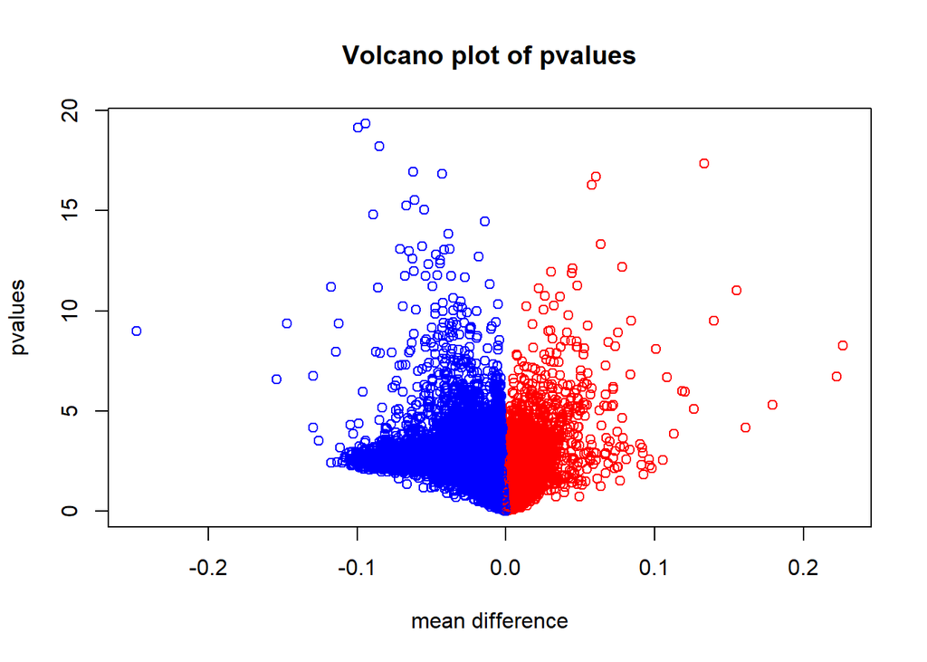

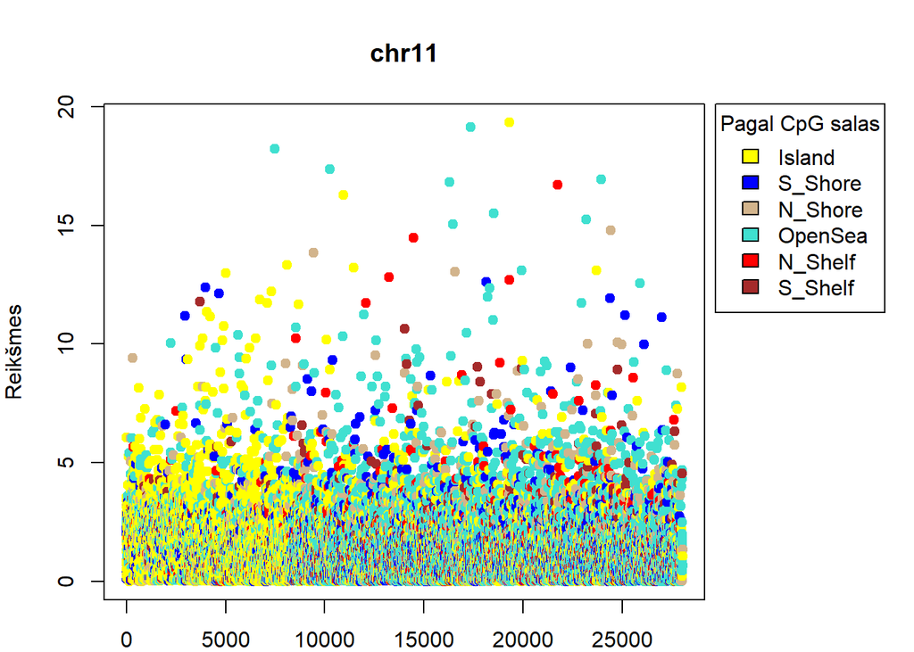